# Project1

Peter

1/12/2020

# Indlæser data

Rename data

## Data wide

Indlæser data til en ‘bred’ matrix med 302 kolonner, en med person, en med repetition og 300 med X Y Z.

!!! Data is sorted in a weird way

## Data for eexperiment 5

Indlæser data til en ‘bred’ matrix med 302 kolonner, en med person, en med repetition og 300 med X Y Z.

|  | persons | reps | x_1 | x_2 | x_3 | x_4 | x_5 | x_6 | x_7 | x_8 | x_9 | x_10 | x_11 | x_12 | x_13 | x_14 | x_15 | x_16 | x_17 | x_18 | x_19 | x_20 | x_21 | x_22 | x_23 | x_24 | x_25 | x_26 | x_27 | … |
| --- | --- | --- | --- | --- | --- | --- | --- | --- | --- | --- | --- | --- | --- | --- | --- | --- | --- | --- | --- | --- | --- | --- | --- | --- | --- | --- | --- | --- | --- | --- |
| 1 | person1 | 1 | 0.6358349 | 0.6206943 | 0.6185483 | 0.5692867 | 0.48128886 | 0.35347623 | 0.30423501 | 0.2747404 | 0.3086035 | 0.3933897 | 0.5387485 | 0.6973881 | 0.8266370 | 0.9649747 | 1.11409675 | 1.31162708 | 1.54390014 | 1.8125912 | 2.12939140 | 2.4968936 | 2.9357107 | 3.4344115 | 3.9885560 | 4.5959525 | 5.2446114 | 5.9391560 | 6.667588 | … |
| 2 | person1 | 2 | 0.1563258 | 0.1403309 | 0.1323591 | 0.1261030 | 0.08554632 | 0.01737618 | -0.07716672 | -0.1556568 | -0.2489180 | -0.3349403 | -0.4410130 | -0.5312304 | -0.5796796 | -0.5809239 | -0.54640656 | -0.48553952 | -0.35815420 | -0.1663646 | 0.03175433 | 0.2456655 | 0.5514341 | 0.8408880 | 1.1848040 | 1.5478253 | 1.8730936 | 2.2630586 | 2.716198 | … |
| 3 | person1 | 3 | -0.6899970 | -0.7254979 | -0.7215743 | -0.7553745 | -0.78246638 | -0.76415688 | -0.68539462 | -0.6221470 | -0.5347818 | -0.4496377 | -0.3749128 | -0.2917495 | -0.2227104 | -0.1780268 | -0.10489072 | -0.03729527 | 0.06067991 | 0.2052054 | 0.39878733 | 0.6381119 | 0.9233231 | 1.2535984 | 1.6119466 | 1.9932462 | 2.4140263 | 2.8873523 | 3.439290 | … |
| 4 | person1 | 4 | -0.3510966 | -0.3873996 | -0.3827088 | -0.4236075 | -0.47315078 | -0.50951971 | -0.58496936 | -0.6103576 | -0.6067426 | -0.6127661 | -0.5407056 | -0.4372533 | -0.3301387 | -0.1858466 | -0.05177537 | 0.06681160 | 0.21496211 | 0.3988809 | 0.62394664 | 0.8094007 | 1.0740527 | 1.4270483 | 1.8319116 | 2.3075346 | 2.8334172 | 3.3955900 | 3.986880 | … |
| 5 | person1 | 5 | -0.3601385 | -0.3714402 | -0.4297921 | -0.4789298 | -0.60017033 | -0.66413818 | -0.76268454 | -0.8216566 | -0.8637316 | -0.8741179 | -0.8564411 | -0.8241068 | -0.7904043 | -0.6960394 | -0.59541401 | -0.48504488 | -0.33039089 | -0.1332611 | 0.09523312 | 0.3897411 | 0.7322917 | 1.1023055 | 1.5156111 | 1.9772253 | 2.4729281 | 3.0122661 | 3.601015 | … |
| 6 | person1 | 6 | -0.6889861 | -0.6806788 | -0.7436908 | -0.7866221 | -0.83780280 | -0.91790264 | -1.07781930 | -1.2150968 | -1.3373982 | -1.3953245 | -1.4457919 | -1.4341917 | -1.4319232 | -1.3979908 | -1.34833799 | -1.26427595 | -1.17200825 | -1.1074332 | -1.02793243 | -0.9345516 | -0.7916286 | -0.6005883 | -0.3798841 | -0.1196799 | 0.2065359 | 0.5858571 | 1.027420 | … |

## Data long

Indlæser data som en ‘lang’ matrix med 7 kolonner - En med experiment, en med person, en med repition, en med tid og tre med X Y Z.

|  | Experiment | Person | Repetition | Time | X | Y | Z |
| --- | --- | --- | --- | --- | --- | --- | --- |
| 40001 | 5 | 1 | 1 | 1 | 0.6358349 | -1.091573 | 22.37746 |
| 40002 | 5 | 1 | 1 | 2 | 0.6206943 | -1.077204 | 22.36890 |
| 40003 | 5 | 1 | 1 | 3 | 0.6185483 | -1.086094 | 22.38763 |
| 40004 | 5 | 1 | 1 | 4 | 0.5692867 | -1.116746 | 22.39233 |
| 40005 | 5 | 1 | 1 | 5 | 0.4812889 | -1.149489 | 22.41938 |
| 40006 | 5 | 1 | 1 | 6 | 0.3534762 | -1.182350 | 22.47530 |

# Plots 3D!!!

# Standardization

```
##                            PC1      PC2      PC3      PC4      PC5      PC6
## Standard deviation     9.50746 7.016021 6.332579 5.325824 4.443183 4.122986
## Proportion of Variance 0.30131 0.164080 0.133670 0.094550 0.065810 0.056660
## Cumulative Proportion  0.30131 0.465390 0.599060 0.693610 0.759410 0.816080
##                             PC7      PC8     PC9     PC10
## Standard deviation     3.620318 2.947492 2.44348 2.336765
## Proportion of Variance 0.043690 0.028960 0.01990 0.018200
## Cumulative Proportion  0.859770 0.888730 0.90863 0.926830
```

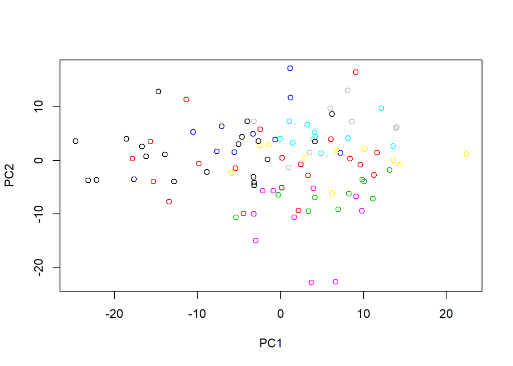

# PCA - test

# Machine learning

Methods

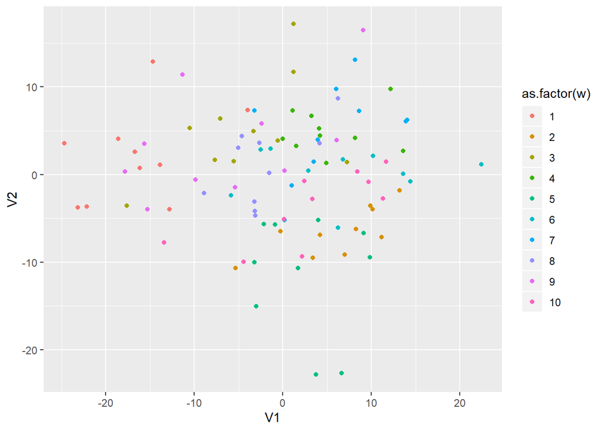

```
## [1] 94.59803 69.80852 63.00836 52.99128 44.20911 41.02320
```

# Cross-Validation KNN (1 Neighbour) & Logistic Regression

*Korrekt brug af McNemar? Binomial eller med continuity correction*  
*Konfidens intervaller - Beta funktion?*

```
## [1] 1
## [1] 2
## [1] 3
## [1] 4
## [1] 5
## [1] 6
## [1] 7
## [1] 8
## [1] 9
## [1] 10
```

```
##    acc_KNN acc_LogReg
##       0.65       0.70
```

## McNemar

```
## Confidence interval for logistic regression
```

```
##      est    lwr.ci    upr.ci
## [1,] 0.7 0.6054535 0.7831586
```

```
## Confidence interval for KNN
```

```
##       est    lwr.ci    upr.ci
## [1,] 0.65 0.5533032 0.7381544
```

```
## Result of McNemars test
```

```
##
##  McNemar's Chi-squared test with continuity correction
##
## data:  contingency
## McNemar's chi-squared = 0.48485, df = 1, p-value = 0.4862
```

```
## P-value obtained via a binomial dsitribution
```

```
## [1] 0.4868502
```

# Punkt 2 - Statistik

Test om der er signifikant effekt af ‘experiment’ på de resulterende kurver.

Beregner mean-curve for hvert eksperiment.

Mange one sample t-test, hvor længden imellem hvert punkt i hvert eksperiment sammenlignes. Nul-hypotese: den gennemsnitlige afstande imellem punkterne i to kurver er 0. Resultatet giver en dataframe rækker svarene til sammenligning af samtlige kombinationer af de 16 eksperimenter. Konfidens intervaller.  
*One sample t-test med afstand i mellem punkter?* *ANOVA - Forskel i mean af X, Y og Z eksperimenterne imellem*

|  | Experiments | Lower | Upper | P-value | Adjusted P-values |
| --- | --- | --- | --- | --- | --- |
| 1 | 1-2 | 2.5535055437809 | 3.58596933914459 | 1.003177e-22 | 1.064297e-20 |
| 2 | 1-3 | 4.99679844288711 | 7.0542294864 | 1.004054e-22 | 1.064297e-20 |
| 3 | 1-4 | 0.835354858871977 | 1.09504690920276 | 1.034017e-20 | 6.410903e-19 |
| 4 | 1-5 | 1.9271484537106 | 2.70430141937155 | 1.049821e-19 | 1.483043e-18 |
| 5 | 1-6 | 4.22678785805151 | 5.98070844750721 | 1.084544e-19 | 1.483043e-18 |
| 6 | 1-7 | 1.47257417735164 | 2.01262808385636 | 1.086913e-20 | 6.630168e-19 |

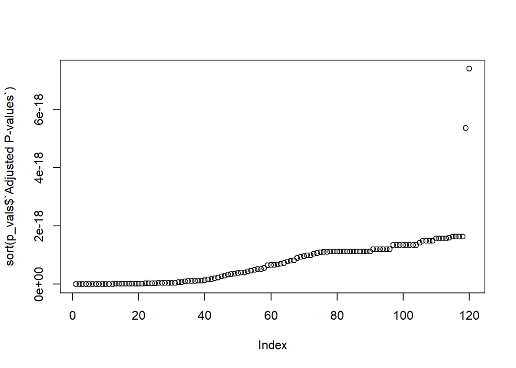

# ANOVA

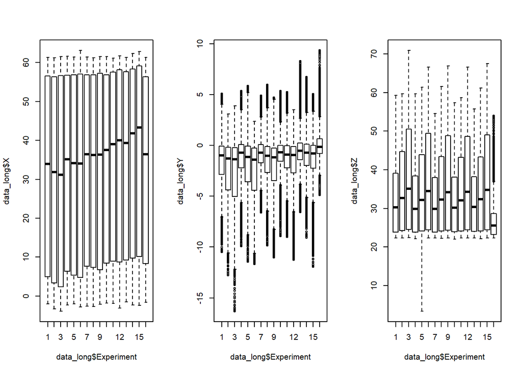

```
##                 Df   Sum Sq Mean Sq F value Pr(>F)
## Experiment      15   382641   25509   46.03 <2e-16 ***
## Residuals   159984 88651482     554
## ---
## Signif. codes:  0 '***' 0.001 '**' 0.01 '*' 0.05 '.' 0.1 ' ' 1
```

```
##
## Call:
## aov(formula = X ~ Experiment, data = data_long)
##
## Residuals:
##     Min      1Q  Median      3Q     Max
## -38.174 -25.680   4.068  24.168  31.698
##
## Coefficients:
##              Estimate Std. Error t value Pr(>|t|)
## (Intercept)   31.2392     0.2354 132.707  < 2e-16 ***
## Experiment2   -0.9331     0.3329  -2.803 0.005066 **
## Experiment3   -1.2666     0.3329  -3.805 0.000142 ***
## Experiment4    0.7041     0.3329   2.115 0.034417 *
## Experiment5    0.2391     0.3329   0.718 0.472668
## Experiment6    0.1574     0.3329   0.473 0.636456
## Experiment7    1.4160     0.3329   4.253 2.11e-05 ***
## Experiment8    1.2696     0.3329   3.814 0.000137 ***
## Experiment9    1.2527     0.3329   3.763 0.000168 ***
## Experiment10   1.8688     0.3329   5.614 1.98e-08 ***
## Experiment11   2.5248     0.3329   7.584 3.36e-14 ***
## Experiment12   2.9094     0.3329   8.740  < 2e-16 ***
## Experiment13   2.7483     0.3329   8.255  < 2e-16 ***
## Experiment14   3.6888     0.3329  11.081  < 2e-16 ***
## Experiment15   4.4846     0.3329  13.471  < 2e-16 ***
## Experiment16   1.4290     0.3329   4.292 1.77e-05 ***
## ---
## Signif. codes:  0 '***' 0.001 '**' 0.01 '*' 0.05 '.' 0.1 ' ' 1
##
## Residual standard error: 23.54 on 159984 degrees of freedom
## Multiple R-squared:  0.004298,   Adjusted R-squared:  0.004204
## F-statistic: 46.04 on 15 and 159984 DF,  p-value: < 2.2e-16
```

```
## $Experiment
##              diff         lwr         upr        p adj
## 2-1   -0.93308341 -2.07362815  0.20746133 2.670653e-01
## 3-1   -1.26656205 -2.40710678 -0.12601731 1.350947e-02
## 4-1    0.70414898 -0.43639576  1.84469372 7.556410e-01
## 5-1    0.23907416 -0.90147058  1.37961890 9.999974e-01
## 6-1    0.15735082 -0.98319392  1.29789556 1.000000e+00
## 7-1    1.41597947  0.27543473  2.55652421 2.237106e-03
## 8-1    1.26963309  0.12908835  2.41017782 1.305318e-02
## 9-1    1.25270842  0.11216368  2.39325316 1.575214e-02
## 10-1   1.86883132  0.72828658  3.00937606 2.348998e-06
## 11-1   2.52482877  1.38428403  3.66537351 4.111600e-12
## 12-1   2.90944126  1.76889652  4.04998600 1.293410e-13
## 13-1   2.74827754  1.60773281  3.88882228 1.967315e-13
## 14-1   3.68881595  2.54827121  4.82936069 7.460699e-14
## 15-1   4.48462313  3.34407839  5.62516787 0.000000e+00
## 16-1   1.42897235  0.28842761  2.56951709 1.890915e-03
## 3-2   -0.33347864 -1.47402337  0.80706610 9.998045e-01
## 4-2    1.63723239  0.49668765  2.77777713 1.006267e-04
## 5-2    1.17215757  0.03161283  2.31270231 3.670296e-02
## 6-2    1.09043423 -0.05011051  2.23097897 7.939160e-02
## 7-2    2.34906288  1.20851814  3.48960762 2.052414e-10
## 8-2    2.20271650  1.06217176  3.34326123 4.402914e-09
## 9-2    2.18579183  1.04524709  3.32633657 6.200200e-09
## 10-2   2.80191473  1.66136999  3.94245947 1.656453e-13
## 11-2   3.45791218  2.31736744  4.59845692 1.381117e-13
## 12-2   3.84252467  2.70197993  4.98306941 0.000000e+00
## 13-2   3.68136095  2.54081622  4.82190569 8.526513e-14
## 14-2   4.62189936  3.48135463  5.76244410 0.000000e+00
## 15-2   5.41770654  4.27716180  6.55825128 0.000000e+00
## 16-2   2.36205576  1.22151102  3.50260050 1.549211e-10
## 4-3    1.97071102  0.83016629  3.11125576 3.845143e-07
## 5-3    1.50563621  0.36509147  2.64618095 6.761523e-04
## 6-3    1.42391287  0.28336813  2.56445761 2.019286e-03
## 7-3    2.68254151  1.54199678  3.82308625 2.984279e-13
## 8-3    2.53619513  1.39565039  3.67673987 3.179457e-12
## 9-3    2.51927047  1.37872573  3.65981521 4.662715e-12
## 10-3   3.13539336  1.99484862  4.27593810 1.471046e-13
## 11-3   3.79139082  2.65084608  4.93193556 0.000000e+00
## 12-3   4.17600331  3.03545857  5.31654805 0.000000e+00
```

[output cut: 67 more lines]

```
## 12-11  0.38461249 -0.75593225  1.52515723 9.989214e-01
## 13-11  0.22344877 -0.91709597  1.36399351 9.999990e-01
## 14-11  1.16398718  0.02344244  2.30453192 3.980638e-02
## 15-11  1.95979436  0.81924962  3.10033910 4.689057e-07
## 16-11 -1.09585642 -2.23640116  0.04468832 7.564426e-02
## 13-12 -0.16116372 -1.30170846  0.97938102 1.000000e+00
## 14-12  0.77937469 -0.36117005  1.91991943 5.925741e-01
## 15-12  1.57518187  0.43463713  2.71572661 2.524377e-04
## 16-12 -1.48046891 -2.62101365 -0.33992418 9.541326e-04
## 14-13  0.94053841 -0.20000633  2.08108315 2.543537e-01
## 15-13  1.73634559  0.59580085  2.87689033 2.143609e-05
## 16-13 -1.31930520 -2.45984994 -0.17876046 7.372583e-03
## 15-14  0.79580718 -0.34473756  1.93635192 5.548062e-01
## 16-14 -2.25984361 -3.40038834 -1.11929887 1.360739e-09
## 16-15 -3.05565078 -4.19619552 -1.91510604 1.876277e-13
```